# Exploratory visulization

## Dataset Overview

### gathering dataset

```python
#Importing Necessary Package for the Project
import pandas as pd
import numpy as np
import matplotlib.pyplot as plt
import seaborn as sb
%matplotlib inline
```

```python
# Reading the dataset
df = pd.read_csv("fordgobike-tripdata.csv")
df.head(2)
```

|  | duration_sec | start_time | end_time | start_station_id | start_station_name | start_station_latitude | start_station_longitude | end_station_id | end_station_name | end_station_latitude | end_station_longitude | bike_id | user_type | bike_share_for_all_trip |
| --- | --- | --- | --- | --- | --- | --- | --- | --- | --- | --- | --- | --- | --- | --- |
| 0 | 50305 | 2019-04-30 22:33:55.1550 | 2019-05-01 12:32:20.4540 | 368.0 | Myrtle St at Polk St | 37.785434 | -122.419622 | 324.0 | Union Square (Powell St at Post St) | 37.788300 | -122.408531 | 2749 | Subscriber | No |
| 1 | 53725 | 2019-04-30 20:43:41.6320 | 2019-05-01 11:39:06.9170 | 246.0 | Berkeley Civic Center | 37.869060 | -122.270556 | 241.0 | Ashby BART Station | 37.852477 | -122.270213 | 2608 | Customer | No |

```python
#Getting Information about dataset
df.info()
```

```
<class 'pandas.core.frame.DataFrame'>
RangeIndex: 239111 entries, 0 to 239110
Data columns (total 14 columns):
 #   Column                   Non-Null Count   Dtype
---  ------                   --------------   -----
 0   duration_sec             239111 non-null  int64
 1   start_time               239111 non-null  object
 2   end_time                 239111 non-null  object
 3   start_station_id         239047 non-null  float64
 4   start_station_name       239047 non-null  object
 5   start_station_latitude   239111 non-null  float64
 6   start_station_longitude  239111 non-null  float64
 7   end_station_id           239047 non-null  float64
 8   end_station_name         239047 non-null  object
 9   end_station_latitude     239111 non-null  float64
 10  end_station_longitude    239111 non-null  float64
 11  bike_id                  239111 non-null  int64
 12  user_type                239111 non-null  object
 13  bike_share_for_all_trip  239111 non-null  object
dtypes: float64(6), int64(2), object(6)
memory usage: 25.5+ MB
```

```python
#Making a copy of original dataset
df_copy = df.copy()
```

```python
#Checking for null values
df_copy.isnull().sum()
```

```
duration_sec                0
start_time                  0
end_time                    0
start_station_id           64
start_station_name         64
start_station_latitude      0
start_station_longitude     0
end_station_id             64
end_station_name           64
end_station_latitude        0
end_station_longitude       0
bike_id                     0
user_type                   0
bike_share_for_all_trip     0
dtype: int64
```

```python
#Removing Null Values
df_copy.dropna(inplace = True)
```

```python
#Rechecking For null values if present after removing
df_copy.isnull().sum()
```

```
duration_sec               0
start_time                 0
end_time                   0
start_station_id           0
start_station_name         0
start_station_latitude     0
start_station_longitude    0
end_station_id             0
end_station_name           0
end_station_latitude       0
end_station_longitude      0
bike_id                    0
user_type                  0
bike_share_for_all_trip    0
dtype: int64
```

```python
#Checking start_station_name values
df_copy["start_station_name"].value_counts()
```

```
San Francisco Caltrain Station 2  (Townsend St at 4th St)    4866
Market St at 10th St                                         4609
San Francisco Ferry Building (Harry Bridges Plaza)           4270
Berry St at 4th St                                           3994
Montgomery St BART Station (Market St at 2nd St)             3550
                                                             ...
Auzerais Ave at Los Gatos Creek Trail                          10
Farnam St at Fruitvale Ave                                      9
17th St at Santa Clara St                                       8
Delmas Ave at Virginia St                                       5
SF Test Station                                                 1
Name: start_station_name, Length: 357, dtype: int64
```

```python
# Converting it into category datatype
df_copy["start_station_name"]=df_copy["start_station_name"].astype('category')
```

```python
#Checking values
df_copy["end_station_name"].value_counts()
```

```
San Francisco Caltrain Station 2  (Townsend St at 4th St)    7115
San Francisco Ferry Building (Harry Bridges Plaza)           4885
Market St at 10th St                                         4598
Montgomery St BART Station (Market St at 2nd St)             4541
Berry St at 4th St                                           3881
                                                             ...
Farnam St at Fruitvale Ave                                     11
San Pedro St at Hedding St                                     11
Auzerais Ave at Los Gatos Creek Trail                           9
Delmas Ave at Virginia St                                       7
17th St at Santa Clara St                                       7
Name: end_station_name, Length: 358, dtype: int64
```

```python
# Converting it into category datatype
df_copy["end_station_name"]=df_copy["end_station_name"].astype('category')
```

```python
# Checking values
df_copy["user_type"].value_counts()
```

```
Subscriber    203185
Customer       35862
Name: user_type, dtype: int64
```

```python
# Converting it into category datatype
df_copy["user_type"] = df_copy["user_type"].astype('category')
```

```python
# geting information
df_copy.info()
```

```
<class 'pandas.core.frame.DataFrame'>
Int64Index: 239047 entries, 0 to 239110
Data columns (total 14 columns):
 #   Column                   Non-Null Count   Dtype
---  ------                   --------------   -----
 0   duration_sec             239047 non-null  int64
 1   start_time               239047 non-null  object
 2   end_time                 239047 non-null  object
 3   start_station_id         239047 non-null  float64
 4   start_station_name       239047 non-null  category
 5   start_station_latitude   239047 non-null  float64
 6   start_station_longitude  239047 non-null  float64
 7   end_station_id           239047 non-null  float64
 8   end_station_name         239047 non-null  category
 9   end_station_latitude     239047 non-null  float64
 10  end_station_longitude    239047 non-null  float64
 11  bike_id                  239047 non-null  int64
 12  user_type                239047 non-null  category
 13  bike_share_for_all_trip  239047 non-null  object
dtypes: category(3), float64(6), int64(2), object(3)
memory usage: 23.1+ MB
```

```python
# Converting to datetime datatype
df_copy["start_time"]= pd.to_datetime(df_copy["start_time"])
df_copy["end_time"]= pd.to_datetime(df_copy["end_time"])
```

```python
# Extracting year, month and day from start_time
df_copy["starting_year"]= df_copy["start_time"].dt.year
df_copy["starting_month"]= df_copy["start_time"].dt.month
df_copy["starting_day"]= df_copy["start_time"].dt.day
```

```python
# Extracting year, month and day from end_time
df_copy["ending_year"]= df_copy["end_time"].dt.year
df_copy["ending_month"]= df_copy["end_time"].dt.month
df_copy["ending_day"]= df_copy["end_time"].dt.day
```

```python
# Converting Datatype
df_copy["starting_year"]=df_copy["starting_year"].astype('category')
df_copy["starting_month"]=df_copy["starting_month"].astype('category')
df_copy["starting_day"]=df_copy["starting_day"].astype('int')

df_copy["ending_year"]=df_copy["ending_year"].astype('category')
df_copy["ending_month"]=df_copy["ending_month"].astype('category')
df_copy["ending_day"]=df_copy["ending_day"].astype('int')
```

```python
# Checking values
df_copy["bike_share_for_all_trip"].value_counts()
```

```
No     218407
Yes     20640
Name: bike_share_for_all_trip, dtype: int64
```

```python
# Converting it into category datatype
df_copy["bike_share_for_all_trip"]=df_copy["bike_share_for_all_trip"].astype('category')
```

```python
df_copy.head(2)
```

|  | duration_sec | start_time | end_time | start_station_id | start_station_name | start_station_latitude | start_station_longitude | end_station_id | end_station_name | end_station_latitude | end_station_longitude | bike_id | user_type | bike_share_for_all_trip | starting_year | starting_month | starting_day | ending_year | ending_month | ending_day |
| --- | --- | --- | --- | --- | --- | --- | --- | --- | --- | --- | --- | --- | --- | --- | --- | --- | --- | --- | --- | --- |
| 0 | 50305 | 2019-04-30 22:33:55.155 | 2019-05-01 12:32:20.454 | 368.0 | Myrtle St at Polk St | 37.785434 | -122.419622 | 324.0 | Union Square (Powell St at Post St) | 37.788300 | -122.408531 | 2749 | Subscriber | No | 2019 | 4 | 30 | 2019 | 5 | 1 |
| 1 | 53725 | 2019-04-30 20:43:41.632 | 2019-05-01 11:39:06.917 | 246.0 | Berkeley Civic Center | 37.869060 | -122.270556 | 241.0 | Ashby BART Station | 37.852477 | -122.270213 | 2608 | Customer | No | 2019 | 4 | 30 | 2019 | 5 | 1 |

```python
# getting latitidue and logitude difference
df_copy["latitude_diff"] = df_copy["end_station_latitude"]- df_copy["start_station_latitude"]
df_copy["longitude_diff"] = df_copy["end_station_longitude"]- df_copy["start_station_longitude"]
```

```python
# Creating a categorical column base on above difference
df_copy["north_south"]= df_copy.latitude_diff.apply(lambda x : "North" if x > 0 else "South")
df_copy["east_west"]= df_copy.longitude_diff.apply(lambda x : "East" if x > 0 else "West")
```

```python
# Converting it into category datatype
df_copy["north_south"] = df_copy["north_south"].astype('category')
df_copy["east_west"] = df_copy["east_west"].astype('category')
```

```python
df_copy.head(2)
```

|  | duration_sec | start_time | end_time | start_station_id | start_station_name | start_station_latitude | start_station_longitude | end_station_id | end_station_name | end_station_latitude | ... | starting_year | starting_month | starting_day | ending_year | ending_month | ending_day | latitude_diff | longitude_diff | north_south | east_west |
| --- | --- | --- | --- | --- | --- | --- | --- | --- | --- | --- | --- | --- | --- | --- | --- | --- | --- | --- | --- | --- | --- |
| 0 | 50305 | 2019-04-30 22:33:55.155 | 2019-05-01 12:32:20.454 | 368.0 | Myrtle St at Polk St | 37.785434 | -122.419622 | 324.0 | Union Square (Powell St at Post St) | 37.788300 | ... | 2019 | 4 | 30 | 2019 | 5 | 1 | 0.002866 | 0.011091 | North | East |
| 1 | 53725 | 2019-04-30 20:43:41.632 | 2019-05-01 11:39:06.917 | 246.0 | Berkeley Civic Center | 37.869060 | -122.270556 | 241.0 | Ashby BART Station | 37.852477 | ... | 2019 | 4 | 30 | 2019 | 5 | 1 | -0.016583 | 0.000343 | South | East |

2 rows × 24 columns

```python
df_copy.info()
```

```
<class 'pandas.core.frame.DataFrame'>
Int64Index: 239047 entries, 0 to 239110
Data columns (total 24 columns):
 #   Column                   Non-Null Count   Dtype
---  ------                   --------------   -----
 0   duration_sec             239047 non-null  int64
 1   start_time               239047 non-null  datetime64[ns]
 2   end_time                 239047 non-null  datetime64[ns]
 3   start_station_id         239047 non-null  float64
 4   start_station_name       239047 non-null  category
 5   start_station_latitude   239047 non-null  float64
 6   start_station_longitude  239047 non-null  float64
 7   end_station_id           239047 non-null  float64
 8   end_station_name         239047 non-null  category
 9   end_station_latitude     239047 non-null  float64
```

[output cut: 16 more lines]

#### This is final and clean dataset for the project

### Univarients

- The most popular starting station for riding rental bike was " San Francisco Caltrain Station 2(Townsend St at 4th St)" with about 5000 bike riders starting from there

```
0.020355829606730057
```

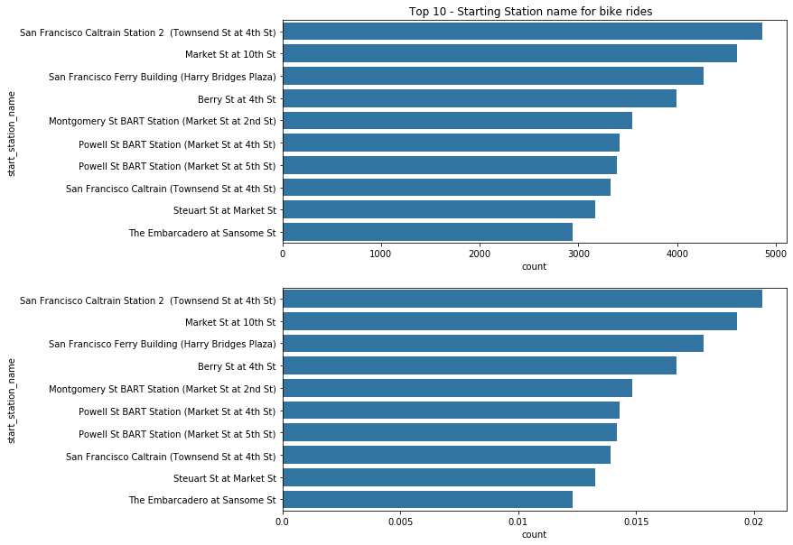

```python
plt.figure(figsize = [10, 10])

plt.subplot(2,1,1)
base_color = sb.color_palette()[0]
sb.countplot(data = df_copy, y = 'start_station_name', color = base_color,
             order =df_copy ['start_station_name'].value_counts().head(10).index );
plt.title("Top 10 - Starting Station name for bike rides  ");


#Relative Frequency for the Top 10 - Starting Station name for bike rides
plt.subplot(2,1,2)
n_count = df_copy.shape[0]
max_count = df_copy["start_station_name"].value_counts().max()
max_prop = max_count/n_count
print(max_prop)

location = np.arange(0, max_prop, .005)
tick_name = ['{}'.format(v) for v in location ]
sb.countplot(data = df_copy, y = 'start_station_name', color = base_color,
             order =df_copy ['start_station_name'].value_counts().head(10).index );
base_color = sb.color_palette()[0]

#plt.xticks(rotation = 90)
plt.xticks(location*n_count, tick_name);
```

- The most popular ending station for riding rental bike was " San Francisco Caltrain Station 2(Townsend St at 4th St)" with about 7000 bike riders ending on it

```
0.02976402130125038
```

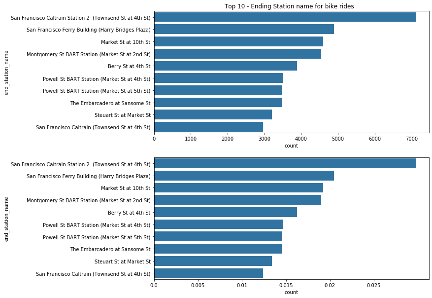

```python
plt.figure(figsize = [10, 10])

plt.subplot(2,1,1)
base_color = sb.color_palette()[0]
sb.countplot(data = df_copy, y = 'end_station_name', color = base_color,
             order =df_copy ['end_station_name'].value_counts().head(10).index );
plt.title("Top 10 - Ending Station name for bike rides  ");


#Relative Frequency for the Top 10 - Starting Station name for bike rides
plt.subplot(2,1,2)
n_count = df_copy.shape[0]
max_count = df_copy["end_station_name"].value_counts().max()
max_prop = max_count/n_count
print(max_prop)

location = np.arange(0, max_prop, .005)
tick_name = ['{}'.format(v) for v in location ]
sb.countplot(data = df_copy, y = 'end_station_name', color = base_color,
             order =df_copy ['end_station_name'].value_counts().head(10).index );
base_color = sb.color_palette()[0]

#plt.xticks(rotation = 90)
plt.xticks(location*n_count, tick_name);
```

- 85% of the riders that rented the bike were the subscriber of the company where as just 15% were casul customer

```python
sorted_counts = df_copy["user_type"].value_counts()
sorted_counts
```

```
Subscriber    203185
Customer       35862
Name: user_type, dtype: int64
```

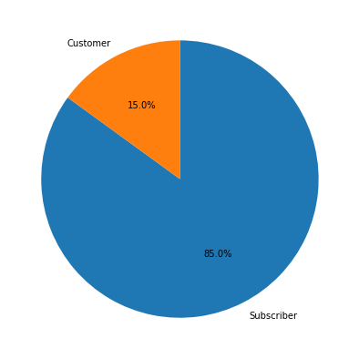

```python
plt.figure(figsize = [7, 7])
plt.pie(sorted_counts, labels= sorted_counts.index, startangle=90, counterclock = False, autopct=('%1.1f%%'));
```

- the maximum time a rider has made is 86114 sec (about 24 hours) , least time rider mafe was just 61 sec(just 1 min) . however the average time spend by riders was 802 sec (a bit more 13 min)

```python
df_copy["duration_sec"].describe()
```

```
count    239047.000000
mean        802.448431
std        1989.807584
min          61.000000
25%         349.000000
50%         558.000000
75%         876.000000
max       86114.000000
Name: duration_sec, dtype: float64
```

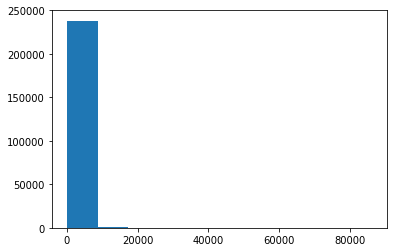

```python
plt.hist(data= df_copy, x ="duration_sec" );
```

```python
np.log10(df_copy['duration_sec'].describe())
```

```
count    5.378483
mean     2.904417
std      3.298811
min      1.785330
25%      2.542825
50%      2.746634
75%      2.942504
max      4.935074
Name: duration_sec, dtype: float64
```

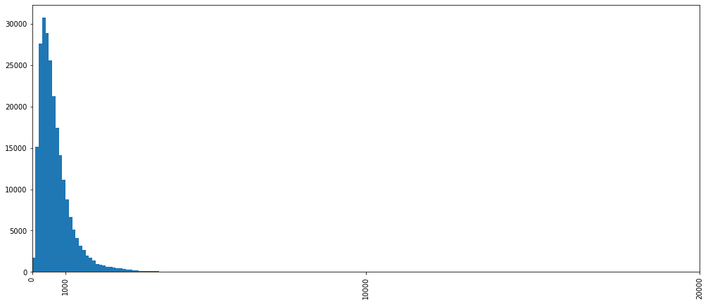

```python
plt.figure(figsize = [17, 7])
bin_edges = np.arange(0, df_copy['duration_sec'].max(), 100)
plt.hist(data =df_copy, x = 'duration_sec', bins = bin_edges);
plt.xlim(0,1000)
ticks = [0,1000, 10000, 20000]
labels=['{}'.format(v) for v in ticks]
plt.xticks(rotation=90)
plt.xticks(ticks,labels);
```

## Bivarients

```python
print(df_copy["starting_month"].value_counts())
print(df_copy["ending_month"].value_counts())
```

```
4    239047
Name: starting_month, dtype: int64
4    239033
5        14
Name: ending_month, dtype: int64
```

- For almost any day in month the duration of riding the rented bike by the riders looks same

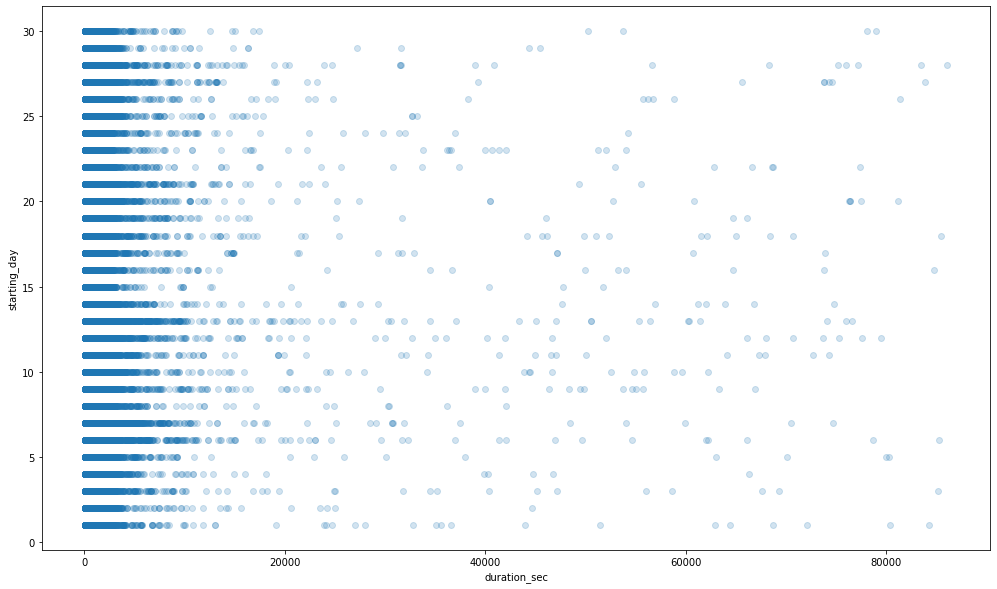

```python
# Plotting an scatter plot for duration_Sec and starting day
plt.figure(figsize = [17, 10])
sb.regplot(data = df_copy , x="duration_sec", y="starting_day",x_jitter=0.3, scatter_kws={'alpha':.2}, fit_reg = False)
```

```
(0, 10000)
```

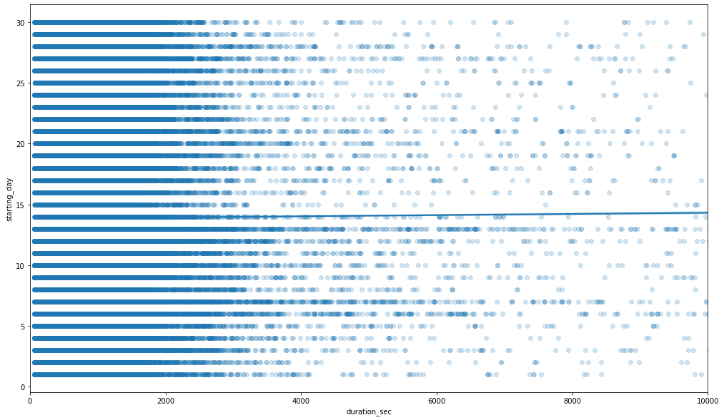

```python
#Plooting scatter plot of duration_sec and starting_day limiting to just 10000 sec as most of the riders ride less than it
plt.figure(figsize = [17, 10])
sb.regplot(data = df_copy , x="duration_sec", y="starting_day",x_jitter=0.3, scatter_kws={'alpha':.2})
plt.xlim(0,10000)
```

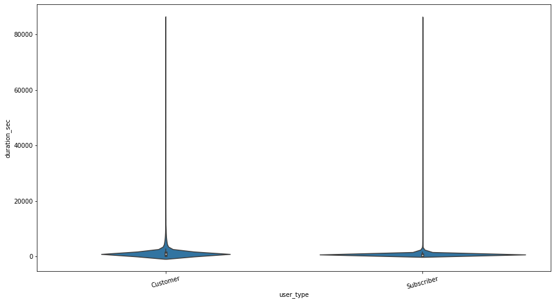

```python
#Plooting A violin plot for user type and duration_sec
plt.figure(figsize = [15, 8])
base_color = sb.color_palette()[0]
sb.violinplot(data = df_copy, x = 'user_type', y = 'duration_sec', color = base_color)
plt.xticks(rotation = 15);
```

- However Customer type of user has higher median of riding duration and inter quartile range in compare to subscriber

```
(0, 10000)
```

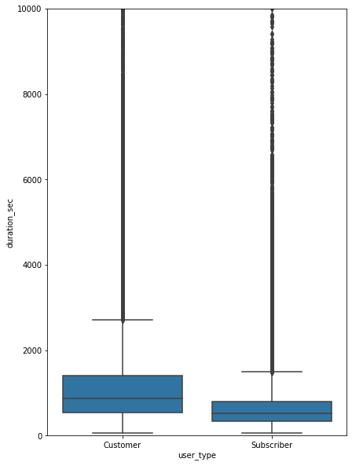

```python
#Plotting a box chat for user-type and duration_sec
plt.figure(figsize = [15, 10])


plt.subplot(1,2,2)
sb.boxplot(data = df_copy, x = 'user_type', y = 'duration_sec', color = base_color);
plt.ylim(0,10000)
```

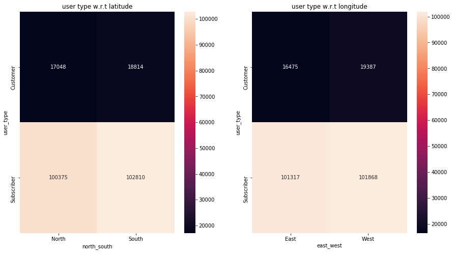

```python
plt.figure(figsize = [15, 8])

#plotting an heat map for user type w.r.t latitude
plt.subplot(1,2,1)

ct_counts = df_copy.groupby(["user_type","north_south"]).size()
ct_counts =ct_counts.reset_index(name="count")
ct_counts = ct_counts.pivot(index="user_type", columns='north_south' , values="count" )
sb.heatmap(ct_counts, annot = True, fmt = 'd');
plt.title('user type w.r.t latitude')


# plotting an heat map for user type w.r.t longitude
plt.subplot(1,2,2)
ct_counts = df_copy.groupby(["user_type","east_west"]).size()
ct_counts =ct_counts.reset_index(name="count")
ct_counts = ct_counts.pivot(index="user_type", columns='east_west' , values="count" )
sb.heatmap(ct_counts, annot = True, fmt = 'd');
plt.title('user type w.r.t longitude')
```

- Using the rented bike , highest number of people goes to south-west where as north-east, south-east and noth-west comes to 2nd , 3rd and 4th respectively

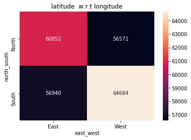

```python
#Plotting a heat map for longitude w.r.t latitude
ct_counts = df_copy.groupby(["north_south","east_west"]).size()
ct_counts =ct_counts.reset_index(name="count")
ct_counts = ct_counts.pivot(index="north_south", columns='east_west' , values="count" )
sb.heatmap(ct_counts, annot = True, fmt = 'd');
plt.title('latitude  w.r.t longitude')
```

### Multivariant

- people riding a bike for about 30 min(2000 sec ) goesmore to south-west part any other direction .

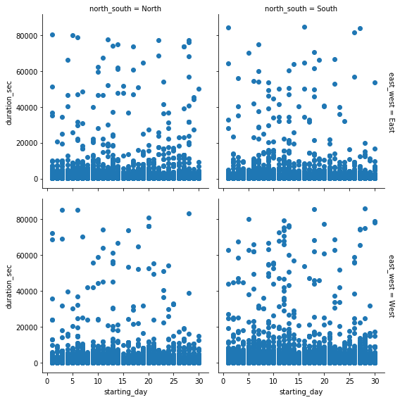

```python
g = sb.FacetGrid(data=df_copy, col = "north_south", row="east_west", size = 4, margin_titles =True)
g.map(plt.scatter,"starting_day","duration_sec")
```

- Its seems like day of the month doest affect the duration of ride for bith tyoe of user as all seems similar for each day

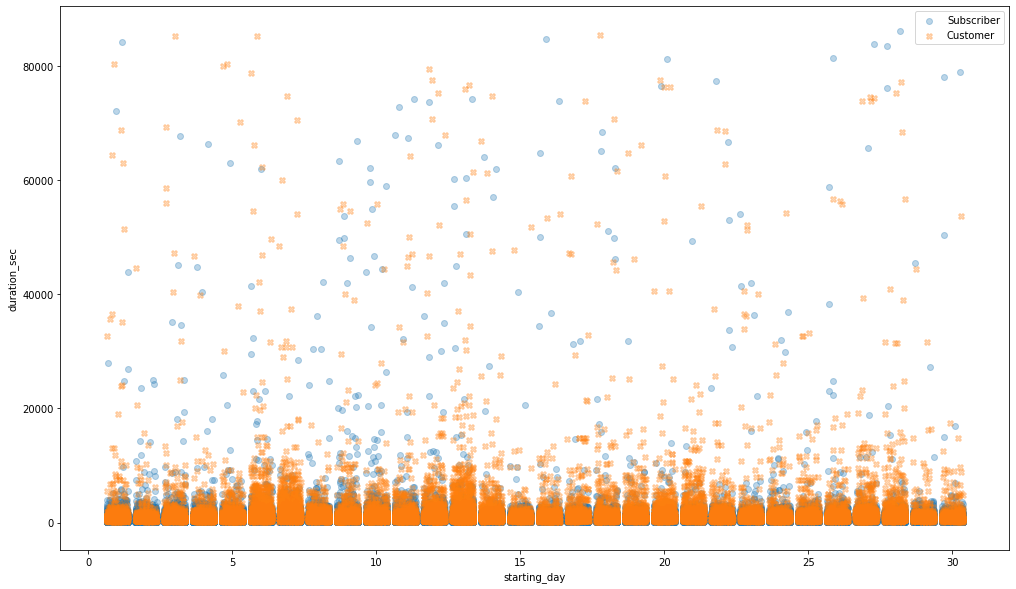

```python
#Plotting a scatter plot using shape to add a categorical variable
plt.figure(figsize = [17, 10])

ttype_markers =[["Subscriber","o"],
               ["Customer","X"]]

for ttype,marker in ttype_markers:
    plot_data = df_copy.loc[df_copy["user_type"]==ttype]
    sb.regplot(data = plot_data , x="starting_day", y="duration_sec",x_jitter=0.37, scatter_kws={'alpha':.3} , fit_reg= False,  marker=marker)

plt.legend(["Subscriber","Customer"])
```